# Explore Flight Delay Time of BOS and SFO in 2019

## by Bokai Xu

## Investigation Overview

> I fly in between BOS and SFO since I am a graduate student at Boston and my girl friend works at SanFrancisco. It is annoying to have a delay flight so I decided to check what influence the delay of flights.

## Dataset Overview

> This data set contains the flights delay reason and delay time of BOS and SFO from Jan. 2019 to Dec. 2019. I did some plots to figure out whether the average flight delay time is influenced by the time of flight delay. Also is there a difference of the delay pattern between Boston and San Francisco.

## (Visualization 1)

> These plots are not very meaningful. They show that how many rows in the table each airport and each month has.

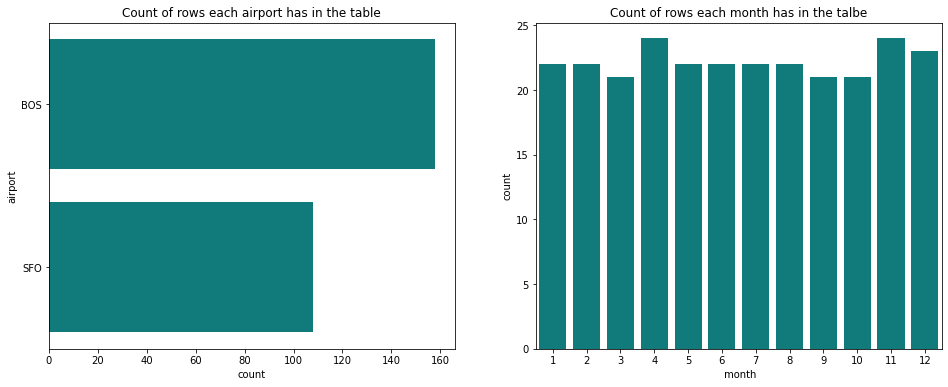

## (Visualization 2)

> From these histograms of average delay time of each month we could see the average delay time most lie in 50 to 100 minutes.

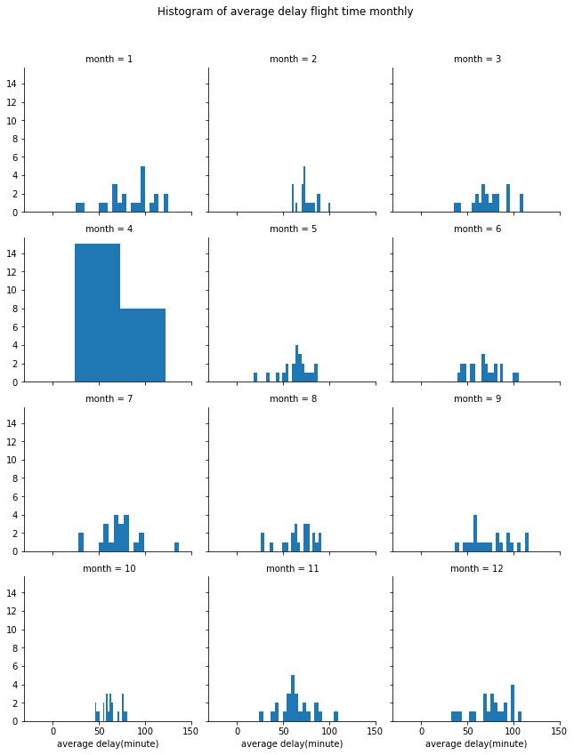

## (Visualization 3)

> From this chart we could see in most month BOS and SFO have similar average flight delay time. In September, the average flight delay time of SFO is obviously higher than the one of BOS. In June, the average flight delay time of SFO is obviously lower than the one of BOS.

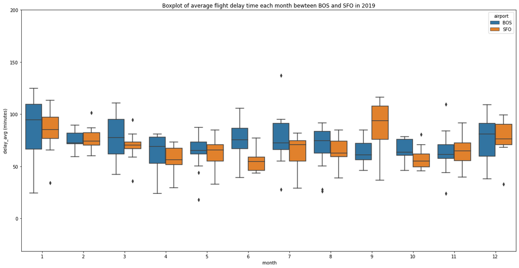

## (Visualization 4)

> From this plot it seems that the higher the times of delay happen, the higher the average flight delay time. This is true in both BOS and SFO.

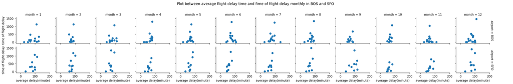